# Practical Machine Learning assignment

Patrick Gottvalles

18.03.2016

## Summary

This project analyzes data from fitness devices (Jawbone, Fitbit, etc.) to predict the manner in which participants are performing a specific movement. Six participants wore accelerometers on the belt, forearm, arm, and dumbbell. Rather than tracking frequency, the data attempts to tracking how well participants performed the activity.

The goal of this project is to accurately predict whether or not the participant performed the activity correctly or incorrectly (the “class” variable) to allow real-time feedback to exercisers wearing training devices.

For this project, the training data was split into a training and a test set. I cleaned and pre-processed the data. After performing some exploratory analysis, I subset the data and removed unnecessary variables. I then fit the relevant subset of the data using trees, random forests, and linear discrimination analysis. The random forests model resulted in the best fit.

## Data Source

Velloso, E.; Bulling, A.; Gellersen, H.; Ugulino, W.; Fuks, H. Qualitative Activity Recognition of Weight Lifting Exercises. Proceedings of 4th International Conference in Cooperation with SIGCHI (Augmented Human ’13) . Stuttgart, Germany: ACM SIGCHI, 2013.

## Data Processing

Participants were asked to perform one set of 10 repetitions of the Unilateral Dumbbell Biceps Curl in five different manners (“classe”). Class “A” corresponds to correct execution of the exercise, while the other 4 classes correspond to common mistakes. According to the researchers, the sensors monitor the movements at a rate of 45Hz, and the data is separated into timed “windows.”

## libraries load

```r
packages <- c("ggplot2", "caret", "data.table", "randomForest", "stats", "scales", "gridExtra")
sapply(packages, require, character.only = TRUE, quietly = TRUE, warn = FALSE)
```

```
##      ggplot2        caret   data.table randomForest        stats
##         TRUE         TRUE        FALSE         TRUE         TRUE
##       scales    gridExtra
##         TRUE         TRUE
```

## Data Extraction

```r
setwd("/home/patrick/Documents/R_Work_Space/MachineLearning")
raw_train_dat <- read.csv("pml-training.csv", na.strings=c("#DIV/0!", "", "NA"), strip.white=T, header=TRUE)
raw_test_dat <- read.csv("pml-testing.csv", na.strings=c("#DIV/0!", "", "NA"), strip.white=T, header=TRUE)
```

## Data Cleaning

```r
dataset_row_nb<-dim(raw_train_dat)[1] # calculate the number of rows in the raw_train_dat dataset
col_name_80p_na<-(colSums(is.na(raw_train_dat)) > 0.9*dataset_row_nb) # list columns were more thant 80% of the row are NA

# remove such columns from both training and testing datasets
raw_train_dat<-raw_train_dat[, !(col_name_80p_na)]
raw_test_dat<-raw_test_dat[, !(col_name_80p_na)]
```

The first 7 columns are only for bookkeeping and therefore do not have any value for this exercice: Let’s remove them accordingly

```r
#removing book keeping columns
raw_train_dat<-raw_train_dat[, -c(1:7)]
raw_test_dat<-raw_test_dat[, -c(1:7)]
```

## Exploratory Analysis

There are so many different predictor that it is quite difficult to find any of them that could help identifying any visual trend

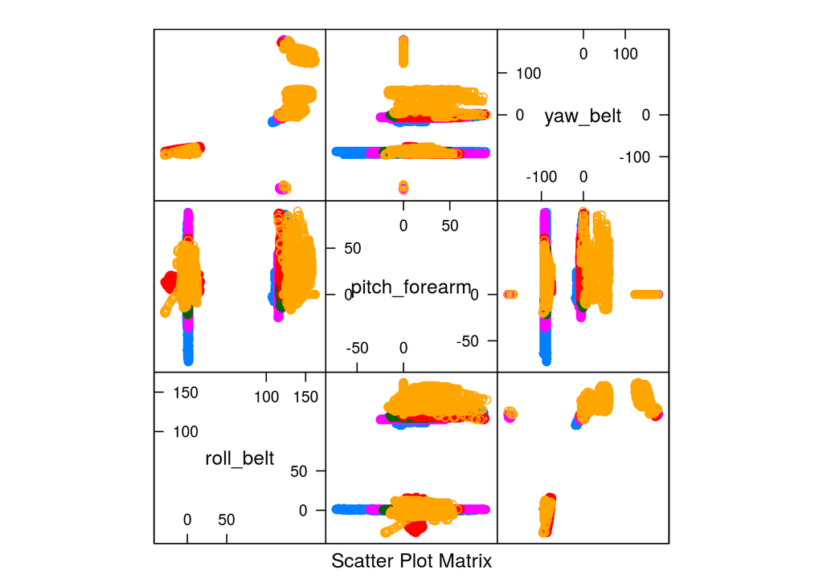

```r
featurePlot(x=raw_train_dat[,c("roll_belt","pitch_forearm","yaw_belt")],y=raw_train_dat$classe,plot="pairs")
```

# Partition Data

The original pml-training set is partitioned into two randomly sampled data sets: training (60%) and testing (40%). This testing set will be used to estimate the out-of-sample error rate to understand how well the model will apply to the validation set, the pml-testing data (ptest).

```r
set.seed(222) #sets the seed
inTrain <- createDataPartition(y=raw_train_dat$classe,p=0.6, list=FALSE)
training <- raw_train_dat[inTrain,]
testing <- raw_train_dat[-inTrain,]
```

# Preprocessing

The dataset is quite large and my laptop is quite old => better to try to get the most importatnt data at the first shot. For that we are going to use the **Principal Component analasys** method **(PCA)**

```r
col_classe_nb<-dim(training)[2] #calculate the # of columns in the dataset
preProc <- preProcess(training[,-col_classe_nb],method="pca",thresh=0.8) #preprocess the data in order to get 80% of the variance
#Let's apply this preProc object to training and testing dataset
trainPC<-predict(preProc,training)
testPC<-predict(preProc,testing)
```

Note that after this pca preprocessing we only need 13 components

```r
preProc
```

```
## Created from 11776 samples and 52 variables
##
## Pre-processing:
##   - centered (52)
##   - ignored (0)
##   - principal component signal extraction (52)
##   - scaled (52)
##
## PCA needed 13 components to capture 80 percent of the variance
```

=>So we will reduce downward the amount of cpu needed for the model calculation

# Model Selection

The goal is to correctly predict the class of movement based on the data. Therefore a classification model is required. Some options include: Trees, Random Forests, and Linear Discriminant Analysis. I use 4-fold cross validation to limit bias, with parallel processing to save computational time.

```r
ctrl <- trainControl(allowParallel=T, method="cv", number=4)
mod_rpart <- train(training$classe ~ ., data=trainPC, trControl=ctrl, method="rpart")
mod_rf <- train(training$classe ~ ., data=trainPC, trControl=ctrl, method="rf",ntree=150) #let's start with 150 tree for now
mod_lda <- train(training$classe ~ ., data=trainPC, trControl=ctrl, method="lda")
resamps <- resamples(list(rpart = mod_rpart, rf = mod_rf, lda = mod_lda))

summary(resamps)$statistics$Accuracy
```

```
##         Min. 1st Qu. Median   Mean 3rd Qu.   Max. NA's
## rpart 0.3494  0.3622 0.3667 0.3668  0.3712 0.3843    0
## rf    0.9361  0.9364 0.9378 0.9380  0.9395 0.9402    0
## lda   0.4635  0.4641 0.4682 0.4710  0.4752 0.4842    0
```

At first sight it seems that random forest model is the one that would give best accurancy.

Note also that it seems 150 trees (as we have selected for the randome forest) is well enough to stabilize the error

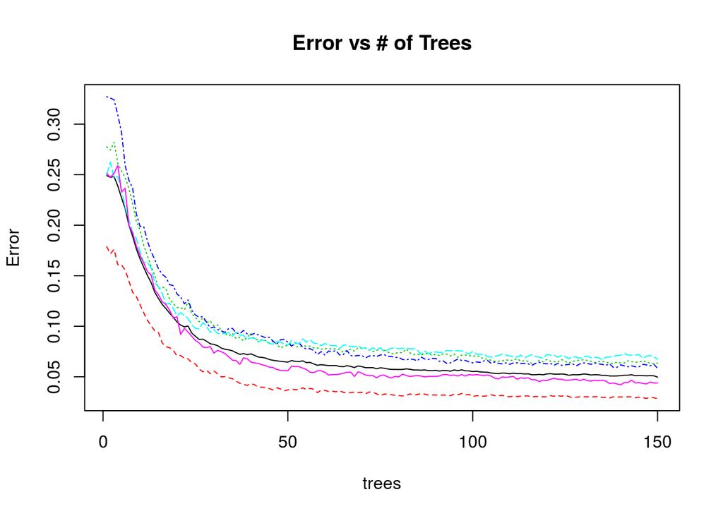

```r
plot(mod_rf$finalModel,main="Error vs # of Trees")
```

Let’s check that more closely by applying those model to the training dataset first rpart - Tree

```r
train_pred_rpart<-predict(mod_rpart,newdata=trainPC)
train_acc_rpart<-confusionMatrix(train_pred_rpart,training$classe)$overall[1]
train_acc_rpart
```

```
##  Accuracy
## 0.3538553
```

random forest

```r
train_pred_rf<-predict(mod_rf,newdata=trainPC)
train_acc_rf<-confusionMatrix(train_pred_rf,training$classe)$overall[1]
train_acc_rf
```

```
## Accuracy
##        1
```

Linear Discrimination Analysis (LDA)

```r
train_pred_lda<-predict(mod_lda,newdata=trainPC)
train_acc_lda<-confusionMatrix(train_pred_lda,training$classe)$overall[1]
train_acc_lda
```

```
##  Accuracy
## 0.4725713
```

As we have suspected, the random forest algorythm is the one that gives the best result on the training set. => let’s see what is the siutation on the testing dataset. We will apply each model on the preprocessed testing dataset **testPC**

Tree - rpart

```r
test_pred_rpart<-predict(mod_rpart,newdata=testPC)
test_acc_rpart<-confusionMatrix(test_pred_rpart,testing$classe)$overall[1]
test_acc_rpart
```

```
##  Accuracy
## 0.3459087
```

Random forest

```r
test_pred_rf<-predict(mod_rf,newdata=testPC)
test_acc_rf<-confusionMatrix(test_pred_rf,testing$classe)$overall[1]
test_acc_rf
```

```
## Accuracy
## 0.954754
```

LDA

```r
test_pred_lda<-predict(mod_lda,newdata=testPC)
test_acc_lda<-confusionMatrix(test_pred_lda,testing$classe)$overall[1]
test_acc_lda
```

```
##  Accuracy
## 0.4650777
```

=> Once again, the random forest seems to have the best accurancy

## Data prediction on raw_test_dat dataset

Lets see what it gives for the raw_test_data

```r
raw_test_dat_PC<-predict(preProc,raw_test_dat)
raw_test_pred_rf<-predict(mod_rf,newdata=raw_test_dat_PC)
raw_test_pred_rf
```

```
##  [1] B A B A A E D B A A A C B A E E A B B B
## Levels: A B C D E
```

## Model Tunning

The current random forest model is good but it quite slow, as shown the computation time is 75.902.

```r
mod_rf$times[1]
```

```
## $everything
##    user  system elapsed
##  75.902   0.303  77.533
```

Therefore there would be need to see if we could get more efficiency in terms of perfermance. First let’s plot the model and how it behaves

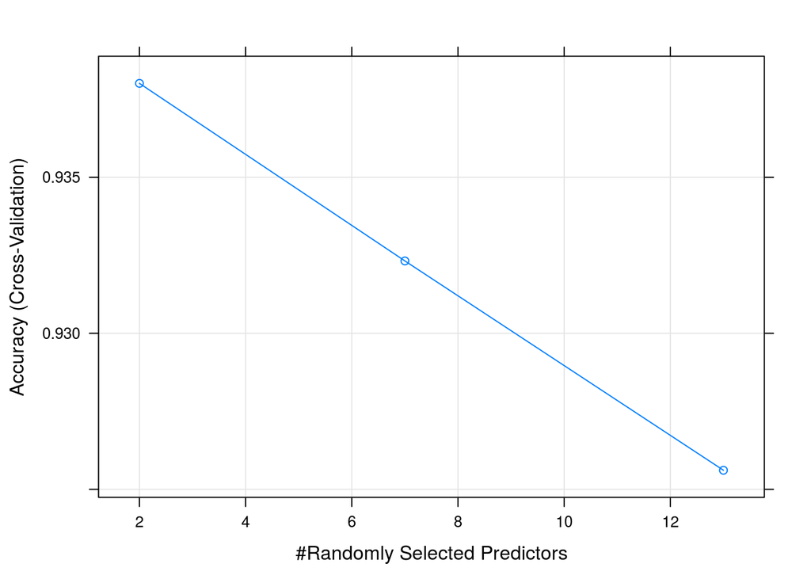

```r
plot(mod_rf)
```

As we have applied a pca processing to the dataset, It seems that with even 2 predictors we could have 94% of accurancy.

By using the varimp function we can get the most important predictors in the model

let’s plot the important variable of the model

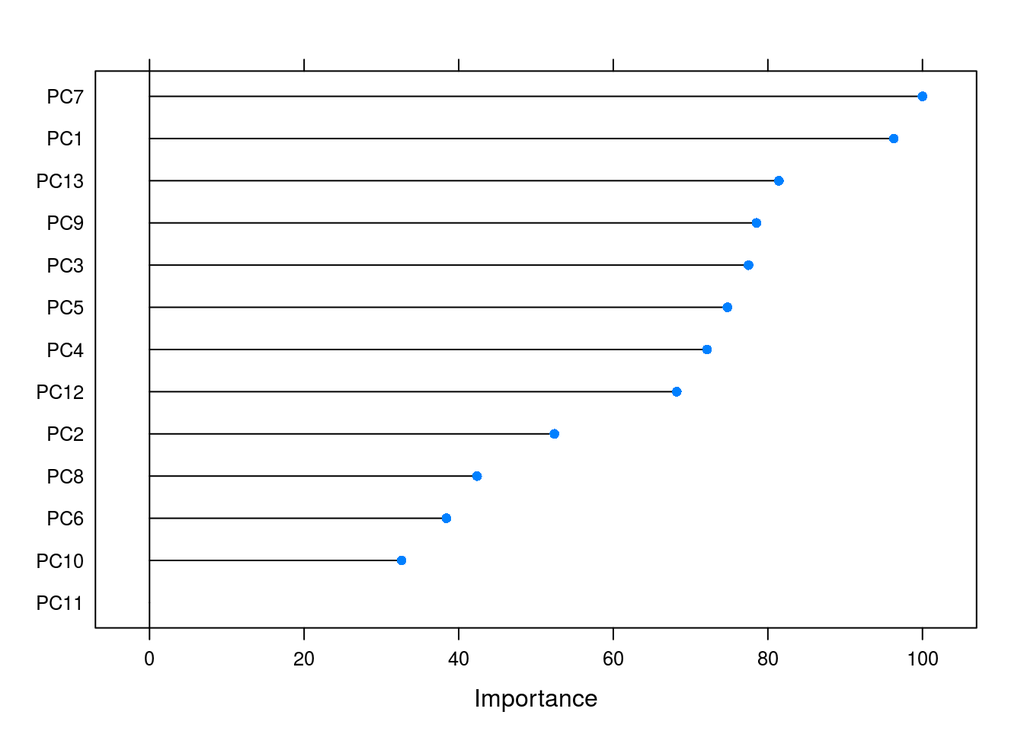

```r
plot(varImp(mod_rf))
```

Seemes like taking the 6 most important predictors would give us a good accurancy/performance ration: Let’s try it

```r
ImpMeasure<-data.frame(varImp(mod_rf)$importance)
ImpMeasure$Vars<-row.names(ImpMeasure)
ImpMeasure[order(-ImpMeasure$Overall),][1:6,]
```

```
##        Overall Vars
## PC7  100.00000  PC7
## PC1   96.28943  PC1
## PC13  81.42005 PC13
## PC9   78.52709  PC9
## PC3   77.49425  PC3
## PC5   74.76896  PC5
```

```r
imp_pred<-ImpMeasure[order(-ImpMeasure$Overall),][1:6,]$Vars
imp_pred
```

```
## [1] "PC7"  "PC1"  "PC13" "PC9"  "PC3"  "PC5"
```

```r
new_trainPC<-cbind(trainPC[imp_pred],trainPC$classe)
names(new_trainPC)<-c(imp_pred, "classe")
new_testPC<-cbind(testPC[imp_pred],testPC$classe)
names(new_testPC)<-c(imp_pred, "classe")
```

refit the model with the new dataset with randowm forest method

```r
new_mod_rf<-train(training$classe ~ ., data=new_trainPC, trControl=ctrl, method="rf",ntree=150)
```

and then calculate the accurancy

```r
test_new_pred_rf<-predict(new_mod_rf,newdata=new_testPC)
test_new_acc_rf<-confusionMatrix(test_new_pred_rf,testing$classe)$overall[1]
test_new_acc_rf
```

```
## Accuracy
## 0.875478
```

So the original random forest mode has the following accurancy and computation time * accurancy : 0.954754 * computation time : 75.902

we can see that we have accurancy variance of -8.3032973%.

**=> Therfore we can be satisfied with this model tunning**